# Community data analysis using the vegan package in R

August 6, 2017 • ESA 2017

## Workshop logistics

- Etherpad
  - https://public.etherpad-mozilla.org/p/ESA2017-intro-vegan

## Workshop logistics

- Etherpad
  - https://public.etherpad-mozilla.org/p/ESA2017-intro-vegan
- Red and Green Stickies

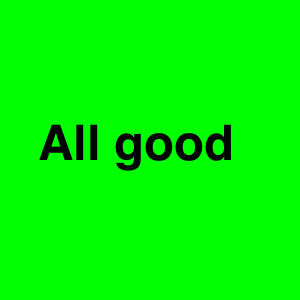

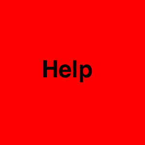

## Packages installed (and loaded)?

```r
install.packages("vegan", dependencies = TRUE)
install.packages("permute")
library("vegan")
```

### Data downloaded from github?

https://github.com/naupaka/esa_intro_vegan_2016

## Introduction to **vegan**

### a potted history

- Jari Oksanen released first version of vegan to CRAN on September 5th 2001
- Limited scope; purpose was to have Peter Minchin's DECODA-like functions for NMDS available in R plus helper functions
- By version 1.4, vegan had DCA & CCA, with RDA following in 1.4.2. `ordisurf()` appeared in 1.4 also as did permutation tests.
- From version 1.6, vegan expanded into areas of theoretical ecology and diversity
- Version 1.6.5 brought the `metaMDS()` wrappers for NMDS
- Since then vegan has rapidly developed on the R-Forge website and expanded considerably
- Current development team: Jari Oksanen, F. Guillaume Blanchet, Roeland Kindt, Pierre Legendre, Peter R. Minchin, R. B. O'Hara, Gavin L. Simpson, Peter Solymos, M. Henry H. Stevens, Helene Wagner

## Introduction to **vegan**

### vegan today

- The current stable release is version 2.4-0 which is available from CRAN
- http://cran.r-project.org/web/packages/vegan
- Development is mainly conducted via [github](https://github.com/vegandevs/vegan) with a separate development version
- Github also hosts our bug tracking, but we use R-Forge for mailing lists & forums which should be first port of call for getting help
- http://r-forge.r-project.org/projects/vegan
- Also several vignettes (manuals/guides) containing R code to explain how vegan works
- The vegan tutorial is available at http://vegan.r-forge.r-project.org

## Digging in

### Prepping your data for R and vegan

### “The purpose of computing is insight, not numbers”

### - Richard Hamming

## Digging in

### Prepping your data for R and vegan

### “The purpose of computing is insight, not numbers”

### - Richard Hamming

But you have to get through the numbers to get to the insight…

## Digging in

### Prepping your data for R and vegan

We've all heard data horror stories

[figure not shown]

## Cleaning and importing data

## Loading data and then checking

```r
setwd("your/working/directory/")
```

## Loading data and then checking

```r
BCI.small.csv.in <- read.csv("data/BCI_small_broken.csv", header = TRUE)
summary(BCI.small.csv.in)
```

```
       X         X2.Abarema.macradenium Acacia.melanoceras
 Min.   : 1.00   Min.   :0.0               : 3
 1st Qu.: 5.75   1st Qu.:0.0            0  :14
 Median :10.50   Median :0.0            1  : 5
 Mean   :10.50   Mean   :0.3            N/A: 1
 3rd Qu.:15.25   3rd Qu.:0.0
 Max.   :20.00   Max.   :2.0
 NA's   :3       NA's   :3
                 Acalypha.diversifolia Acalypha.diversifolia.1
                            : 2        Min.   :0.00000
 0                          :18        1st Qu.:0.00000
 3                          : 2        Median :0.00000
 Note to self: get more data: 1        Mean   :0.05556
                                       3rd Qu.:0.00000
                                       Max.   :1.00000
                                       NA's   :5
 Adelia.triloba   X.1                                         Notes
  : 3           Mode:logical                                     :20
 0:11           NA's:23        Rained all day for this one       : 1
 1: 4                          Snakes!                           : 1
 2: 2                          undergrad team collected this plot: 1
 3: 1
 5: 1
 o: 1
```

## Cleaning your data for R and vegan

…worked example…

## Cleaning your data for R and vegan

### Loading cleaned data and then checking

```r
BCI.small.csv.in <- read.csv("data/BCI_small_fixed.csv", header = TRUE, row.names = 1)
```

Then…

```r
head(BCI.small.csv.in, n = 3)
```

```
  Abarema.macradenium Acacia.melanoceras Acalypha.diversifolia
1                   0                  1                     0
2                   1                  0                     0
3                   0                  0                     0
  Acalypha.macrostachya Adelia.triloba
1                     0              0
2                     0              0
3                     1              0
```

## Cleaning your data for R and vegan

Then…

```r
summary(BCI.small.csv.in)
```

```
 Abarema.macradenium Acacia.melanoceras Acalypha.diversifolia
 Min.   :0.0         Min.   :0.00       Min.   :0.0
 1st Qu.:0.0         1st Qu.:0.00       1st Qu.:0.0
 Median :0.0         Median :0.00       Median :0.0
 Mean   :0.3         Mean   :0.25       Mean   :0.3
 3rd Qu.:0.0         3rd Qu.:0.25       3rd Qu.:0.0
 Max.   :2.0         Max.   :1.00       Max.   :3.0
 Acalypha.macrostachya Adelia.triloba
 Min.   :0.00          Min.   :0.0
 1st Qu.:0.00          1st Qu.:0.0
 Median :0.00          Median :0.0
 Mean   :0.05          Mean   :0.8
 3rd Qu.:0.00          3rd Qu.:1.0
 Max.   :1.00          Max.   :5.0
```

## Loading your species by site matrix into R

We will now switch to using a microbial ecology dataset, which we will load directly (from Zimmerman and Vitousek 2012)

```r
MLM.otus <- read.csv("data/MLM_data_otus.csv", row.names = 1, header = TRUE)
MLM.env <- read.csv("data/MLM_data_env.csv", header = TRUE)
```

```r
head(MLM.otus[,1:3], n = 3)
```

```
       OTU_0001 OTU_0002 OTU_0003
w100y1     3430        1       75
w100y2      475       17      609
w100y3       24       12      243
```

## Loading your species by site matrix into R

```r
head(MLM.env[,1:7], n = 3)
```

```
  X Tree_ID site_ID date_collected     UTM_zone Easting Northing
1 1  w100y1   w100y     2009-11-18 NAD83 Zone 5  280572  2179971
2 2  w100y2   w100y     2009-11-18 NAD83 Zone 5  280574  2179975
3 3  w100y3   w100y     2009-11-18 NAD83 Zone 5  280588  2179975
```

## Basic data summarizing

## Summarizing data with `apply()`

### sums and sorting

**Sum of rows**

```r
sum.of.rows <- apply(MLM.otus, 1, sum)
sort(sum.of.rows, decreasing = TRUE)[1:8] #top 8 rows (plots)
```

```
  w700y1   w700o9  w100y10  w1800y2   d700o9 d1700y10   w700o5   w100o1
    7897     7805     7665     7536     7499     7109     7107     7092
```

## Summarizing data with `apply()`

### sums and sorting

**Sum of rows**

```r
sum.of.rows <- apply(MLM.otus, 1, sum)
sort(sum.of.rows, decreasing = TRUE)[1:8] #top 8 rows (plots)
```

```
  w700y1   w700o9  w100y10  w1800y2   d700o9 d1700y10   w700o5   w100o1
    7897     7805     7665     7536     7499     7109     7107     7092
```

**Sum of columns**

```r
sum.of.columns <- apply(MLM.otus, 2, sum)
sort(sum.of.columns, decreasing = TRUE)[1:3] #top 3 columns (species)
```

```
OTU_0001 OTU_0002 OTU_0003
  174612   127234    39710
```

## Summarizing data with `apply()`

### sums and sorting

**Number of plots in which each spp. occurs**

```r
spec.pres <- apply(MLM.otus > 0, 2, sum)
sort(spec.pres, decreasing = TRUE)[1:18]
```

```
OTU_0003 OTU_0002 OTU_0001 OTU_0030 OTU_0011 OTU_0049 OTU_0004 OTU_0029
     119      108      106      105      102       94       87       83
OTU_0038 OTU_0046 OTU_0008 OTU_0005 OTU_0083 OTU_0180 OTU_0034 OTU_0062
      79       77       76       72       68       65       63       63
OTU_0106 OTU_0092
      62       60
```

## Data Transformation

## Basic data transformation

**Square root transformation**

```r
head(MLM.otus[,1:3], n = 3)
```

```
       OTU_0001 OTU_0002 OTU_0003
w100y1     3430        1       75
w100y2      475       17      609
w100y3       24       12      243
```

## Basic data transformation

**Square root transformation**

```r
head(MLM.otus[,1:3], n = 3)
```

```
       OTU_0001 OTU_0002 OTU_0003
w100y1     3430        1       75
w100y2      475       17      609
w100y3       24       12      243
```

```r
spec.sqrt <- sqrt(MLM.otus)
head(spec.sqrt[,1:3], n = 3)
```

```
        OTU_0001 OTU_0002  OTU_0003
w100y1 58.566202 1.000000  8.660254
w100y2 21.794495 4.123106 24.677925
w100y3  4.898979 3.464102 15.588457
```

## Data transformation in vegan with `decostand()`

**Total**

```r
head(MLM.otus[,1:3], n = 3)
```

```
       OTU_0001 OTU_0002 OTU_0003
w100y1     3430        1       75
w100y2      475       17      609
w100y3       24       12      243
```

## Data transformation in vegan with `decostand()`

**Total**

```r
head(MLM.otus[,1:3], n = 3)
```

```
       OTU_0001 OTU_0002 OTU_0003
w100y1     3430        1       75
w100y2      475       17      609
w100y3       24       12      243
```

```r
spec.total <- decostand(MLM.otus, method = "total", MARGIN = 1) # by rows (sites)
head(spec.total[,1:3], n = 3)
```

```
          OTU_0001     OTU_0002   OTU_0003
w100y1 0.781677302 0.0002278943 0.01709207
w100y2 0.089758125 0.0032123961 0.11507937
w100y3 0.004244032 0.0021220159 0.04297082
```

## Data transformation in vegan with `decostand()`

**Maximum**

```r
head(MLM.otus[,1:3], n = 3)
```

```
       OTU_0001 OTU_0002 OTU_0003
w100y1     3430        1       75
w100y2      475       17      609
w100y3       24       12      243
```

## Data transformation in vegan with `decostand()`

**Maximum**

```r
head(MLM.otus[,1:3], n = 3)
```

```
       OTU_0001 OTU_0002 OTU_0003
w100y1     3430        1       75
w100y2      475       17      609
w100y3       24       12      243
```

```r
spec.max <- decostand(MLM.otus, method = "max", MARGIN = 2) # by columns (species)
head(spec.max[,1:3], n = 3)
```

```
          OTU_0001     OTU_0002   OTU_0003
w100y1 0.471153846 0.0001653439 0.01960272
w100y2 0.065247253 0.0028108466 0.15917407
w100y3 0.003296703 0.0019841270 0.06351281
```

## Data transformation in vegan with `decostand()`

**Presence-Absence**

```r
head(MLM.otus[,1:3], n = 3)
```

```
       OTU_0001 OTU_0002 OTU_0003
w100y1     3430        1       75
w100y2      475       17      609
w100y3       24       12      243
```

## Data transformation in vegan with `decostand()`

**Presence-Absence**

```r
head(MLM.otus[,1:3], n = 3)
```

```
       OTU_0001 OTU_0002 OTU_0003
w100y1     3430        1       75
w100y2      475       17      609
w100y3       24       12      243
```

```r
spec.pa <- decostand(MLM.otus, method = "pa")
head(spec.pa[,1:3], n = 3)
```

```
       OTU_0001 OTU_0002 OTU_0003
w100y1        1        1        1
w100y2        1        1        1
w100y3        1        1        1
```

## Data transformation in vegan with `decostand()`

**Hellinger (Legendre & Gallagher 2001)**  
Square root of method "total"

```r
head(MLM.otus[,1:3], n = 3)
```

```
       OTU_0001 OTU_0002 OTU_0003
w100y1     3430        1       75
w100y2      475       17      609
w100y3       24       12      243
```

## Data transformation in vegan with `decostand()`

**Hellinger (Legendre & Gallagher 2001)**  
Square root of method "total"

```r
head(MLM.otus[,1:3], n = 3)
```

```
       OTU_0001 OTU_0002 OTU_0003
w100y1     3430        1       75
w100y2      475       17      609
w100y3       24       12      243
```

```r
spec.hellinger <- decostand(MLM.otus, method = "hellinger", MARGIN = 1) # on rows (sites)
head(spec.hellinger[,1:3], n = 3)
```

```
         OTU_0001   OTU_0002  OTU_0003
w100y1 0.88412516 0.01509617 0.1307366
w100y2 0.29959660 0.05667800 0.3392335
w100y3 0.06514623 0.04606534 0.2072940
```

## Data transformation in vegan with `decostand()`

**Wisconsin double standardization**  
Shortcut function for standardizing species to maximum, then sites by totals.

```r
head(MLM.otus[,1:3], n = 3)
```

```
       OTU_0001 OTU_0002 OTU_0003
w100y1     3430        1       75
w100y2      475       17      609
w100y3       24       12      243
```

## Data transformation in vegan with `decostand()`

**Wisconsin double standardization**  
Shortcut function for standardizing species to maximum, then sites by totals.

```r
head(MLM.otus[,1:3], n = 3)
```

```
       OTU_0001 OTU_0002 OTU_0003
w100y1     3430        1       75
w100y2      475       17      609
w100y3       24       12      243
```

```r
spec.wisc <- wisconsin(MLM.otus)
head(spec.wisc[,1:3], n = 3)
```

```
           OTU_0001     OTU_0002     OTU_0003
w100y1 0.0095409778 3.348254e-06 0.0003969597
w100y2 0.0005553552 2.392466e-05 0.0013548180
w100y3 0.0000395903 2.382749e-05 0.0007627289
```

## Calculating community distances

## Calculating distances with `vegdist()`

### so many distance metrics, so little time!

### Many different community distance metrics are available in `vegdist()`

*manhattan, euclidean, canberra, bray, kulczynski, jaccard, gower, altGower, morisita, horn, mountford, raup, binomial, chao, or cao*

## Calculating distances with `vegdist()`

### so many distance metrics, so little time!

### Many different community distance metrics are available in `vegdist()`

*manhattan, euclidean, canberra, bray, kulczynski, jaccard, gower, altGower, morisita, horn, mountford, raup, binomial, chao, or cao*

```r
spec.jaccpa <- vegdist(MLM.otus, method = "jaccard", binary = TRUE)
# returns an object of class 'dist'
str(spec.jaccpa)
```

```
Class 'dist'  atomic [1:8385] 0.805 0.769 0.78 0.76 0.793 ...
  ..- attr(*, "Size")= int 130
  ..- attr(*, "Labels")= chr [1:130] "w100y1" "w100y2" "w100y3" "w100y4" ...
  ..- attr(*, "Diag")= logi FALSE
  ..- attr(*, "Upper")= logi FALSE
  ..- attr(*, "method")= chr "binary jaccard"
  ..- attr(*, "call")= language vegdist(x = MLM.otus, method = "jaccard", binary = TRUE)
```

## Calculating distances with `vegdist()`

### so many distance metrics, so little time!

```r
as.matrix(spec.jaccpa)[1:4,1:4]
```

[output not shown]

## Calculating distances with `vegdist()`

### so many distance metrics, so little time!

### How to choose a good one for your data set?

### First step, read the help for vegdist

```r
?vegdist
```

## Calculating distances with `vegdist()`

### so many distance metrics, so little time!

### Second, try `rankindex()`

Higher rank correlations indicate better separation along gradients

```r
rank.elev <- rankindex(MLM.env$elevation_m, MLM.otus, indices =
              c("bray", "euclid", "manhattan", "horn"), method = "spearman")
rank.elev
```

```
     bray    euclid manhattan      horn
0.4835205 0.3780230 0.3852126 0.5090748
```

## Calculating distances with `vegdist()`

### so many distance metrics, so little time!

### Second, try `rankindex()`

Can also use on standardized data

```r
rank.elev.wisc <- rankindex(MLM.env$elevation_m, wisconsin(MLM.otus), indices =
              c("bray", "euclid", "manhattan", "horn"), method = "spearman")
rank.elev.wisc
```

```
       bray      euclid   manhattan        horn
 0.45556000 -0.03630866  0.45555990  0.46304968
```

## Calculating distances with `vegdist()`

### comparison

```r
sort(rank.elev, decreasing = TRUE)
```

```
     horn      bray manhattan    euclid
0.5090748 0.4835205 0.3852126 0.3780230
```

```r
sort(rank.elev.wisc, decreasing = TRUE)
```

```
       horn        bray   manhattan      euclid
 0.46304968  0.45556000  0.45555990 -0.03630866
```

## Activity

There is a data file in the workshop repositiory, in the `01-intro-basics/data/` folder called `varespec.xlsx`.

1. Download this file (which has errors)
2. Make a copy
3. Clean it up
4. Load it into R
5. Try at least two different methods to standardize the data.
6. Load the corresponding environmental data with `data(varechem)`
7. Evaluate at least five different community distance metrics with `rankindex()`
8. Calculate community distances using that metric

## Diversity metrics

## Alpha diversity

Basic counts of richness for each plot or site

```r
site.richness <- apply(MLM.otus > 0, 1, sum)
site.richness[1:7]
```

```
w100y1 w100y2 w100y3 w100y4 w100y5 w100y6 w100y7
   140    203    180    126    196    228    154
```

## Alpha diversity

### Other metrics

Fisher's alpha

```r
site.fisher <- fisher.alpha(MLM.otus)
site.fisher[1:7]
```

```
  w100y1   w100y2   w100y3   w100y4   w100y5   w100y6   w100y7
27.58229 41.88171 35.44263 22.43722 38.22437 47.38469 30.18662
```

## Alpha diversity

### Other metrics

Shannon diversity

```r
site.shannon <- diversity(MLM.otus, index = "shannon", MARGIN = 1)
site.shannon[1:7]
```

```
   w100y1    w100y2    w100y3    w100y4    w100y5    w100y6    w100y7
1.3131475 3.6102503 2.8062958 0.8844189 2.1920820 2.9354744 2.5789890
```

## Rarefaction

This is the same as `apply(BCI > 0, MARGIN = 1, sum)`  
it gives the species count for each plot

```r
MLM.S <- specnumber(MLM.otus)
```

This finds the plot with the least number of individuals

```r
# could also use rowsums() instead of apply()
MLM.raremax <- min(apply(MLM.otus, 1, sum))
```

## Rarefaction

Rarefy MLM species matrix to the minimum number of individuals in any plot  
and plot the relationship between observed and rarefied counts (plus add 1-1 line)

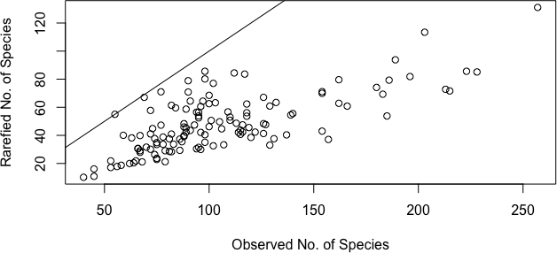

```r
MLM.Srare <- rarefy(MLM.otus, MLM.raremax)
plot(MLM.S, MLM.Srare, xlab = "Observed No. of Species", ylab = "Rarefied No. of Species")
abline(0, 1)
```

## Rarefaction

Put it all together

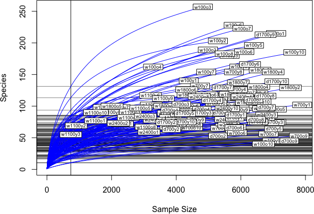

```r
rarecurve(MLM.otus, step = 20, sample = MLM.raremax, col = "blue", cex = 0.6)
```

## Beta diversity

Multivariate homogeneity of groups dispersions

```r
MLM.bray <- vegdist(MLM.otus, method = "bray")
(MLM.bray.bdisp <- betadisper(MLM.bray,group = as.factor(MLM.env$site_ID)))
```

```
    Homogeneity of multivariate dispersions

Call: betadisper(d = MLM.bray, group = as.factor(MLM.env$site_ID))

No. of Positive Eigenvalues: 90
No. of Negative Eigenvalues: 39

Average distance to median:
d1700y  d700o  d700y  w100o  w100y w1100o w1100y w1800o w1800y w2400o
0.4943 0.4630 0.3584 0.4405 0.4516 0.3840 0.4287 0.3647 0.3440 0.2618
w2400y  w700o  w700y
0.2770 0.2800 0.2867

Eigenvalues for PCoA axes:
  PCoA1   PCoA2   PCoA3   PCoA4   PCoA5   PCoA6   PCoA7   PCoA8
15.1299  8.0298  4.2202  2.3315  1.8155  1.5186  1.3340  1.2122
```

## Beta diversity

Multivariate homogeneity of groups dispersions

```r
permutest(MLM.bray.bdisp)
```

```
Permutation test for homogeneity of multivariate dispersions
Permutation: free
Number of permutations: 999

Response: Distances
           Df  Sum Sq  Mean Sq      F N.Perm Pr(>F)
Groups     12 0.75564 0.062970 2.4179    999  0.014 *
Residuals 117 3.04702 0.026043
---
Signif. codes:  0 '***' 0.001 '**' 0.01 '*' 0.05 '.' 0.1 ' ' 1
```

## Beta diversity

Plot of within-group multivariate dispersion

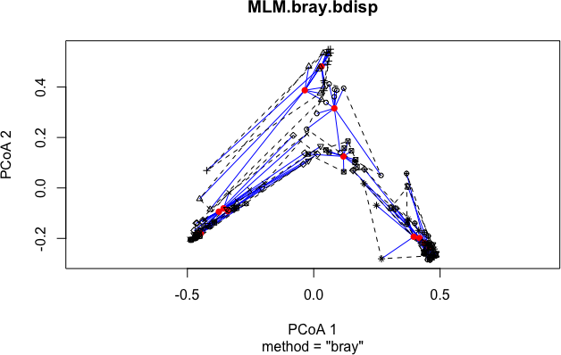

```r
plot(MLM.bray.bdisp)
```

## Beta diversity

Boxplot of within-group multivariate dispersion

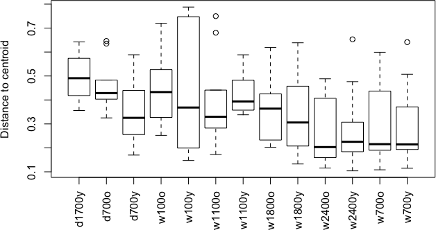

```r
boxplot(MLM.bray.bdisp, las = 3)
```

## Beta diversity

### ANOSIM Analysis of similarities

BE CAREFUL, VERY SENSITIVE TO MULTIVARIATE HETEROSKEDASTICITY

```r
(MLM.bray.anosim <- anosim(MLM.bray, MLM.env$site_ID))
```

```
Call:
anosim(dat = MLM.bray, grouping = MLM.env$site_ID)
Dissimilarity: bray

ANOSIM statistic R: 0.7436
      Significance: 0.001

Permutation: free
Number of permutations: 999
```

## Beta diversity

### ANOSIM Analysis of similarities

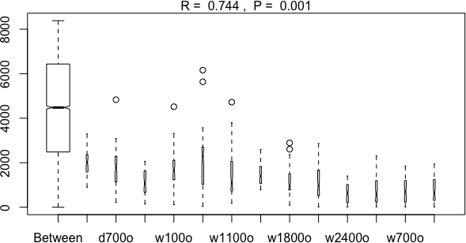

```r
plot(MLM.bray.anosim)
```

## Study design, testing hypotheses, and PERMANOVAs

## PERMANOVA using `adonis`

The key conceptual thing is to decide what is exchangeable (hence permutable) under the null hypothesis you are trying to test.

You can't always test all the things you might be interested in at once in all designs.

## PERMANOVA using `adonis`

Analysis of variance using distance matrices and for fitting linear models to distance matrices

```r
adonis(MLM.otus ~ MLM.env$elevation_m)
```

```
Call:
adonis(formula = MLM.otus ~ MLM.env$elevation_m)

Permutation: free
Number of permutations: 999

Terms added sequentially (first to last)

                     Df SumsOfSqs MeanSqs F.Model      R2 Pr(>F)
MLM.env$elevation_m   1    10.517 10.5173  35.249 0.21592  0.001 ***
Residuals           128    38.192  0.2984         0.78408
Total               129    48.709                 1.00000
---
Signif. codes:  0 '***' 0.001 '**' 0.01 '*' 0.05 '.' 0.1 ' ' 1
```

## PERMANOVA using `adonis`

Thinking about study design and how to permute samples.

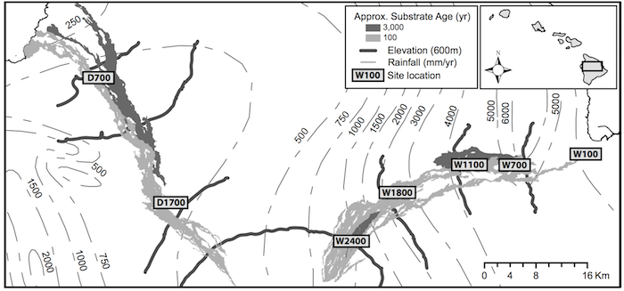

Sites from the Mauna Loa Environmental matrix in Hawai'i.

## PERMANOVA using `adonis`

### Substrate Age

Thinking about study design and how to permute samples (old way using `strata`)

```r
adonis(MLM.otus ~ MLM.env$flow_age, strata = MLM.env$site_ID)
```

```
Call:
adonis(formula = MLM.otus ~ MLM.env$flow_age, strata = MLM.env$site_ID)

Blocks:  strata
Permutation: free
Number of permutations: 999

Terms added sequentially (first to last)

                  Df SumsOfSqs MeanSqs F.Model      R2 Pr(>F)
MLM.env$flow_age   1     1.062 1.06222  2.8536 0.02181      1
Residuals        128    47.647 0.37224         0.97819
Total            129    48.709                 1.00000
```

## PERMANOVA using `adonis`

### Substrate Age

The main thing with `permute` is to understand the levels of the hierarchy:

1. **within**: how to permute samples at lowest level
2. **plots**: how are samples grouped; permutations are restricted to be *within* plots; plots can also be permuted too or instead of samples
3. **blocks**: these sit atop the hierarchy - samples within plots within blocks; blocks are *never* permuted

You can replicate old `strata` arg in vegan's permutation code by setting either `plots` or `blocks` to be a factor variable.

## PERMANOVA using `adonis`

### Substrate Age

Thinking about study design and how to permute samples (new way using `permute` package)

```r
h1 <- how(plots = Plots(MLM.env$site_ID))

# returns max number of permutations given constraints
check(MLM.otus, control = h1)
```

```
[1] 1.891993e+85
```

## PERMANOVA using `adonis`

### Substrate Age

```r
adonis(MLM.otus ~ MLM.env$flow_age, permutations = h1)
```

```
Call:
adonis(formula = MLM.otus ~ MLM.env$flow_age, permutations = h1)

Plots: MLM.env$site_ID, plot permutation: none
Permutation: free
Number of permutations: 199

Terms added sequentially (first to last)

                  Df SumsOfSqs MeanSqs F.Model      R2 Pr(>F)
MLM.env$flow_age   1     1.062 1.06222  2.8536 0.02181      1
Residuals        128    47.647 0.37224         0.97819
Total            129    48.709                 1.00000
```

## PERMANOVA using `adonis`

### Substrate Age

```r
# lots more detail in the help
?how

# check out the new, more flexible, but often slower sister function:
?adonis2
```